# travel-project

```python
# Library to suppress warnings or deprecation notes
import warnings
warnings.filterwarnings('ignore')

# Libraries to help with reading and manipulating data
import numpy as np
import pandas as pd

# Libraries to help with data visualization
import matplotlib.pyplot as plt
%matplotlib inline
import seaborn as sns

# Library to split data
from sklearn.model_selection import train_test_split

# Libraries to import decision tree classifier and different ensemble classifiers
from sklearn.ensemble import BaggingClassifier
from sklearn.ensemble import RandomForestClassifier
from sklearn.tree import DecisionTreeClassifier
from sklearn import tree

# Libtune to tune model, get different metric scores
from sklearn import metrics
from sklearn.metrics import confusion_matrix, classification_report, accuracy_score, precision_score, recall_score,f1_score,roc_auc_score
from sklearn.model_selection import GridSearchCV
```

```python
tourism=pd.read_csv("Tourism.csv") #Import Tourism File
```

```python
# copying data to another varaible to avoid any changes to original data
data=tourism.copy()
```

```python
#Drop data that doesn't give us any useful information
data.drop(['CustomerID'],axis=1,inplace=True)
```

```python
data.head()
```

|  | ProdTaken | Age | TypeofContact | CityTier | DurationOfPitch | Occupation | Gender | NumberOfPersonVisiting | NumberOfFollowups | ProductPitched | PreferredPropertyStar | MaritalStatus | NumberOfTrips | Passport | PitchSatisfactionScore | OwnCar | NumberOfChildrenVisiting | Designation | MonthlyIncome |
| --- | --- | --- | --- | --- | --- | --- | --- | --- | --- | --- | --- | --- | --- | --- | --- | --- | --- | --- | --- |
| 0 | 1 | 41.0 | Self Enquiry | 3 | 6.0 | Salaried | Female | 3 | 3.0 | Deluxe | 3.0 | Single | 1.0 | 1 | 2 | 1 | 0.0 | Manager | 20993.0 |
| 1 | 0 | 49.0 | Company Invited | 1 | 14.0 | Salaried | Male | 3 | 4.0 | Deluxe | 4.0 | Divorced | 2.0 | 0 | 3 | 1 | 2.0 | Manager | 20130.0 |
| 2 | 1 | 37.0 | Self Enquiry | 1 | 8.0 | Free Lancer | Male | 3 | 4.0 | Basic | 3.0 | Single | 7.0 | 1 | 3 | 0 | 0.0 | Executive | 17090.0 |
| 3 | 0 | 33.0 | Company Invited | 1 | 9.0 | Salaried | Female | 2 | 3.0 | Basic | 3.0 | Divorced | 2.0 | 1 | 5 | 1 | 1.0 | Executive | 17909.0 |
| 4 | 0 | NaN | Self Enquiry | 1 | 8.0 | Small Business | Male | 2 | 3.0 | Basic | 4.0 | Divorced | 1.0 | 0 | 5 | 1 | 0.0 | Executive | 18468.0 |

```python
data.shape
```

```
(4888, 19)
```

```python
data.info()
```

```
<class 'pandas.core.frame.DataFrame'>
RangeIndex: 4888 entries, 0 to 4887
Data columns (total 19 columns):
 #   Column                    Non-Null Count  Dtype
---  ------                    --------------  -----
 0   ProdTaken                 4888 non-null   int64
 1   Age                       4662 non-null   float64
 2   TypeofContact             4863 non-null   object
 3   CityTier                  4888 non-null   int64
 4   DurationOfPitch           4637 non-null   float64
 5   Occupation                4888 non-null   object
 6   Gender                    4888 non-null   object
 7   NumberOfPersonVisiting    4888 non-null   int64
 8   NumberOfFollowups         4843 non-null   float64
 9   ProductPitched            4888 non-null   object
 10  PreferredPropertyStar     4862 non-null   float64
 11  MaritalStatus             4888 non-null   object
 12  NumberOfTrips             4748 non-null   float64
 13  Passport                  4888 non-null   int64
 14  PitchSatisfactionScore    4888 non-null   int64
 15  OwnCar                    4888 non-null   int64
 16  NumberOfChildrenVisiting  4822 non-null   float64
 17  Designation               4888 non-null   object
 18  MonthlyIncome             4655 non-null   float64
dtypes: float64(7), int64(6), object(6)
memory usage: 725.7+ KB
```

Inspect various object types

```python
data['TypeofContact'].unique() #nan found
```

```
array(['Self Enquiry', 'Company Invited', nan], dtype=object)
```

```python
data['Occupation'].unique() # candidate for one hot encoding
```

```
array(['Salaried', 'Free Lancer', 'Small Business', 'Large Business'],
      dtype=object)
```

```python
data['Gender'].unique() # Fe Male  is either an error or is meaningful (Example non-binary person)
```

```
array(['Female', 'Male', 'Fe Male'], dtype=object)
```

```python
data['ProductPitched'].unique() # candidate for one hot encoding
```

```
array(['Deluxe', 'Basic', 'Standard', 'Super Deluxe', 'King'],
      dtype=object)
```

```python
data['MaritalStatus'].unique() # one hot encoding candidate
```

```
array(['Single', 'Divorced', 'Married', 'Unmarried'], dtype=object)
```

```python
data['Designation'].unique() # one hot encoding candidate
```

```
array(['Manager', 'Executive', 'Senior Manager', 'AVP', 'VP'],
      dtype=object)
```

```python
#check for nulls
data.isnull().sum().sort_values(ascending=False)
#Dropping rows with NA
data = data.dropna()
```

```python
data.shape
```

```
(4128, 19)
```

```python
data.info()
```

```
<class 'pandas.core.frame.DataFrame'>
Int64Index: 4128 entries, 0 to 4887
Data columns (total 19 columns):
 #   Column                    Non-Null Count  Dtype
---  ------                    --------------  -----
 0   ProdTaken                 4128 non-null   int64
 1   Age                       4128 non-null   float64
 2   TypeofContact             4128 non-null   object
 3   CityTier                  4128 non-null   int64
 4   DurationOfPitch           4128 non-null   float64
 5   Occupation                4128 non-null   object
 6   Gender                    4128 non-null   object
 7   NumberOfPersonVisiting    4128 non-null   int64
 8   NumberOfFollowups         4128 non-null   float64
 9   ProductPitched            4128 non-null   object
 10  PreferredPropertyStar     4128 non-null   float64
 11  MaritalStatus             4128 non-null   object
 12  NumberOfTrips             4128 non-null   float64
 13  Passport                  4128 non-null   int64
 14  PitchSatisfactionScore    4128 non-null   int64
 15  OwnCar                    4128 non-null   int64
 16  NumberOfChildrenVisiting  4128 non-null   float64
 17  Designation               4128 non-null   object
 18  MonthlyIncome             4128 non-null   float64
dtypes: float64(7), int64(6), object(6)
memory usage: 645.0+ KB
```

```python
data.describe().T
```

|  | count | mean | std | min | 25% | 50% | 75% | max |
| --- | --- | --- | --- | --- | --- | --- | --- | --- |
| ProdTaken | 4128.0 | 0.193072 | 0.394757 | 0.0 | 0.0 | 0.0 | 0.0 | 1.0 |
| Age | 4128.0 | 37.231831 | 9.174521 | 18.0 | 31.0 | 36.0 | 43.0 | 61.0 |
| CityTier | 4128.0 | 1.663275 | 0.920640 | 1.0 | 1.0 | 1.0 | 3.0 | 3.0 |
| DurationOfPitch | 4128.0 | 15.584787 | 8.398142 | 5.0 | 9.0 | 14.0 | 20.0 | 127.0 |
| NumberOfPersonVisiting | 4128.0 | 2.949370 | 0.718818 | 1.0 | 2.0 | 3.0 | 3.0 | 5.0 |
| NumberOfFollowups | 4128.0 | 3.741521 | 1.006786 | 1.0 | 3.0 | 4.0 | 4.0 | 6.0 |
| PreferredPropertyStar | 4128.0 | 3.578488 | 0.795031 | 3.0 | 3.0 | 3.0 | 4.0 | 5.0 |
| NumberOfTrips | 4128.0 | 3.295300 | 1.856300 | 1.0 | 2.0 | 3.0 | 4.0 | 22.0 |
| Passport | 4128.0 | 0.295300 | 0.456233 | 0.0 | 0.0 | 0.0 | 1.0 | 1.0 |
| PitchSatisfactionScore | 4128.0 | 3.060804 | 1.363064 | 1.0 | 2.0 | 3.0 | 4.0 | 5.0 |
| OwnCar | 4128.0 | 0.612161 | 0.487317 | 0.0 | 0.0 | 1.0 | 1.0 | 1.0 |
| NumberOfChildrenVisiting | 4128.0 | 1.223595 | 0.852685 | 0.0 | 1.0 | 1.0 | 2.0 | 3.0 |
| MonthlyIncome | 4128.0 | 23178.464147 | 4506.614622 | 1000.0 | 20751.0 | 22418.0 | 25301.0 | 98678.0 |

### EDA - Univariate analysis

```python
# function to plot a boxplot and a histogram along the same scale.

def histogram_boxplot(data, feature, figsize=(12, 7), kde=False, bins=None):
    """
    Boxplot and histogram combined

    data: dataframe
    feature: dataframe column
    figsize: size of figure (default (12,7))
    kde: whether to show the density curve (default False)
    bins: number of bins for histogram (default None)
    """
    f2, (ax_box2, ax_hist2) = plt.subplots(
        nrows=2,  # Number of rows of the subplot grid= 2
        sharex=True,  # x-axis will be shared among all subplots
        gridspec_kw={"height_ratios": (0.25, 0.75)},
        figsize=figsize,
    )  # creating the 2 subplots
    sns.boxplot(
        data=data, x=feature, ax=ax_box2, showmeans=True, color="violet"
    )  # boxplot will be created and a star will indicate the mean value of the column
    sns.histplot(
        data=data, x=feature, kde=kde, ax=ax_hist2, bins=bins, palette="winter"
    ) if bins else sns.histplot(
        data=data, x=feature, kde=kde, ax=ax_hist2
    )  # For histogram
    ax_hist2.axvline(
        data[feature].mean(), color="green", linestyle="--"
    )  # Add mean to the histogram
    ax_hist2.axvline(
        data[feature].median(), color="black", linestyle="-"
    )  # Add median to the histogram
```

### Observations on Age

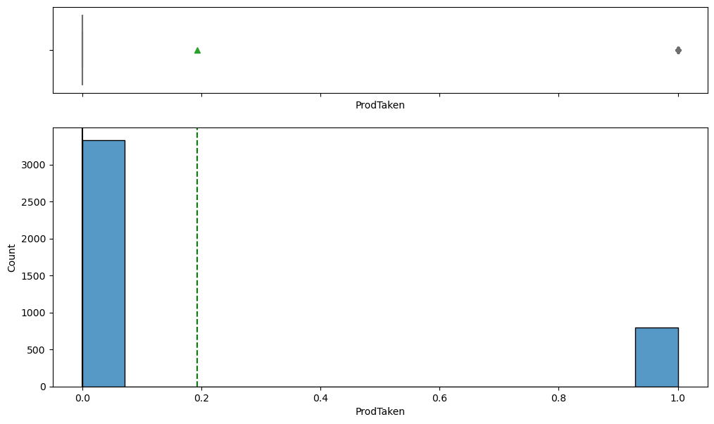

```python
histogram_boxplot(data, "ProdTaken")
```

Most people didn't take the product. In fact less than a 3rd did.

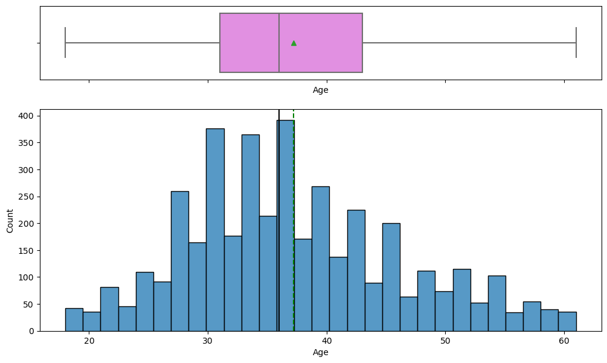

```python
histogram_boxplot(data, "Age")
```

75% of the people are between sometime in their early and mid 40

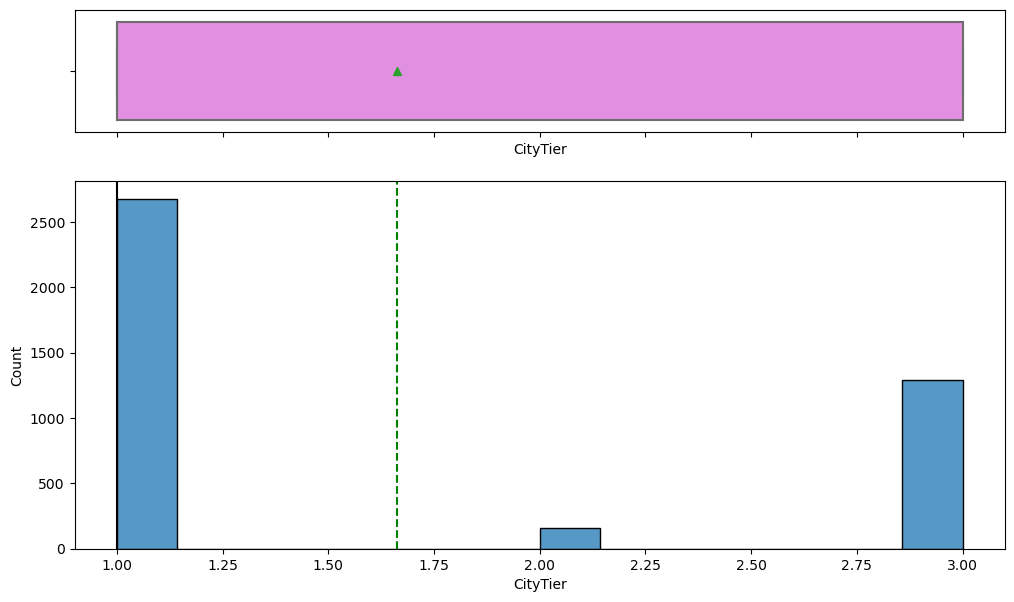

```python
histogram_boxplot(data, "CityTier")
```

Very few city teir 2 rows.

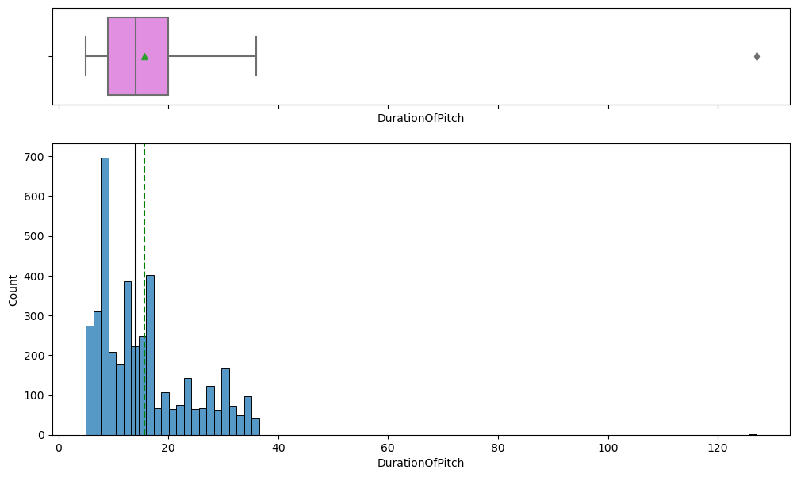

```python
histogram_boxplot(data, "DurationOfPitch")
```

Most pitches are under 40 with the exception of a few outliers.

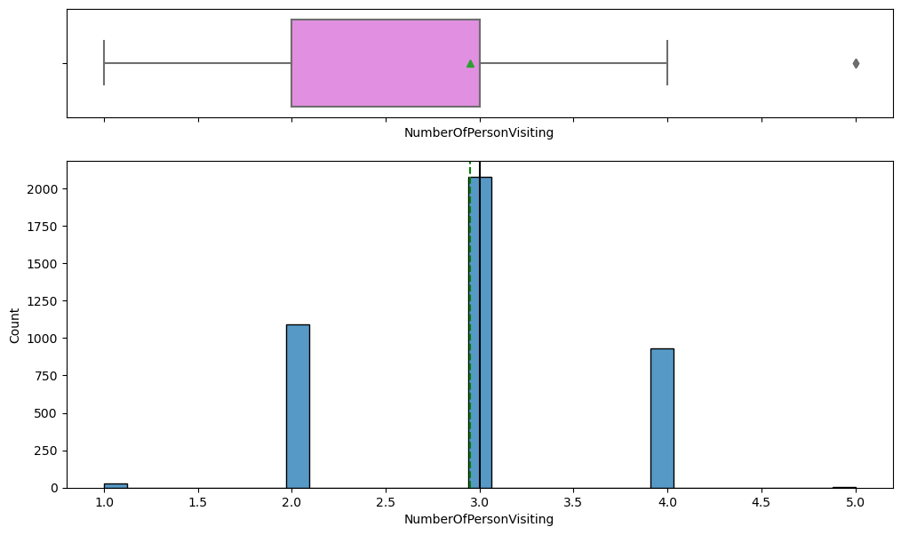

```python
histogram_boxplot(data, "NumberOfPersonVisiting")
```

75 percentile is between 2 and 3 visitors is the highest frequency

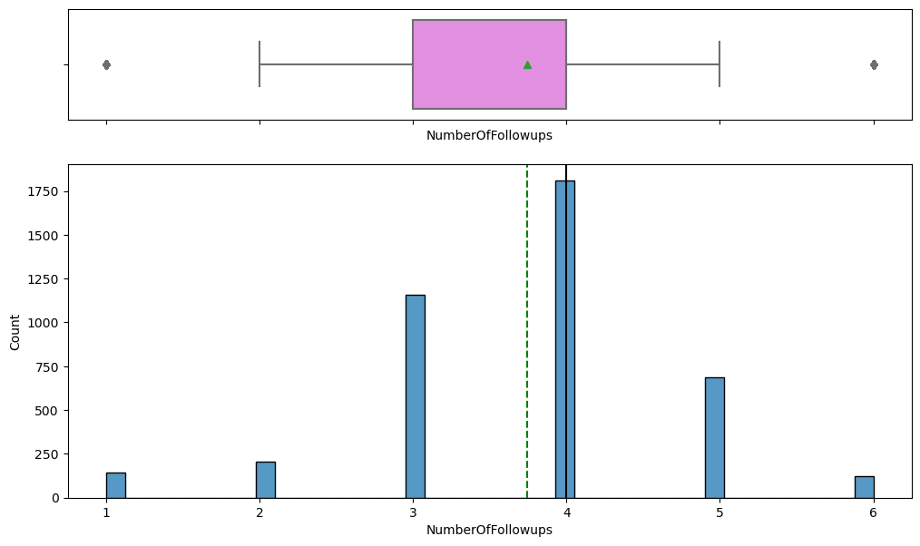

```python
histogram_boxplot(data, "NumberOfFollowups")
```

Number of followups is slightly left schewed with 4 being highest in frequency

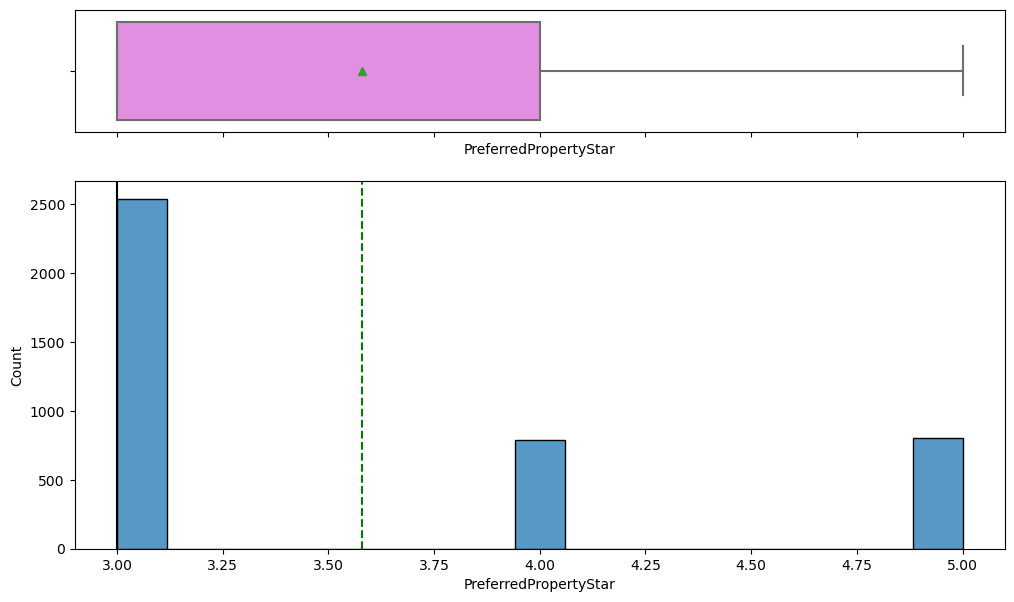

```python
histogram_boxplot(data, "PreferredPropertyStar")
```

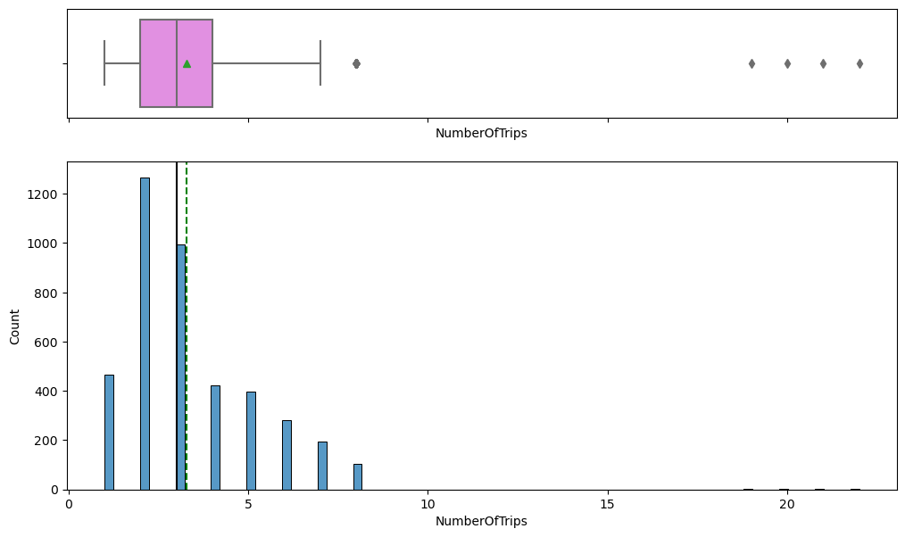

```python
histogram_boxplot(data, "NumberOfTrips")
```

Number of trips taken is right scewed

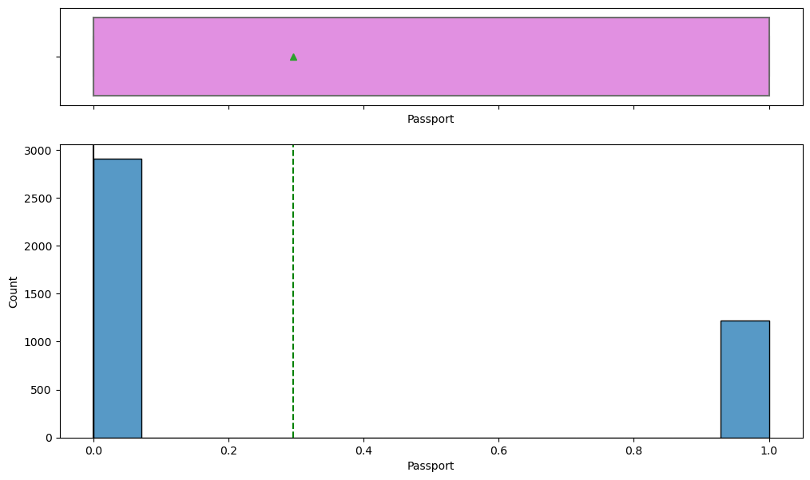

```python
histogram_boxplot(data, "Passport")
```

Most people don't have a passport

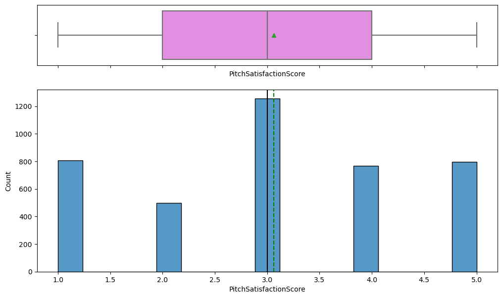

```python
histogram_boxplot(data, "PitchSatisfactionScore")
```

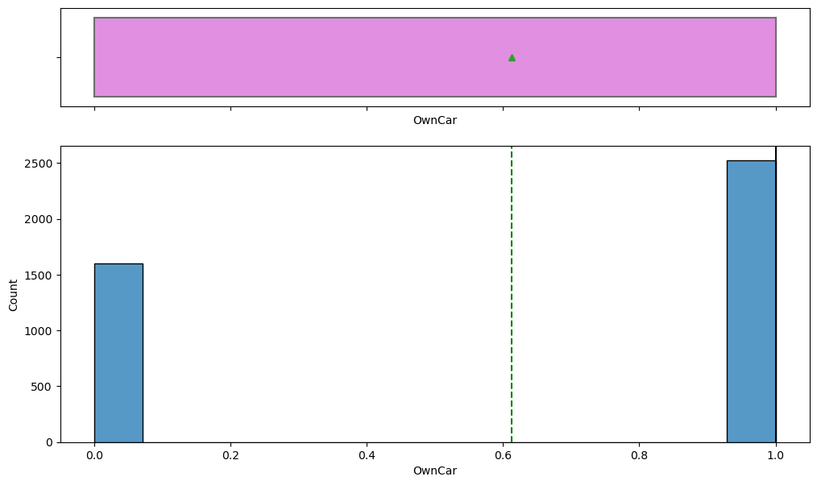

```python
histogram_boxplot(data, "OwnCar")
```

Most people own a car

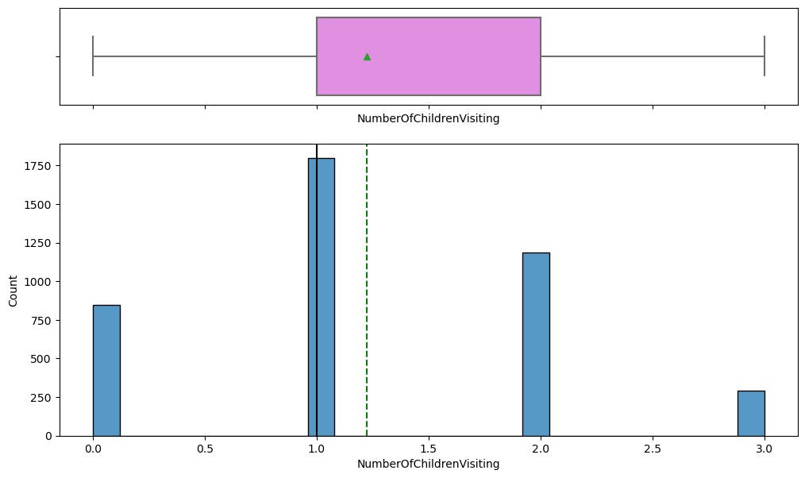

```python
histogram_boxplot(data, "NumberOfChildrenVisiting")
```

Most frequent number of visitors that are children is one

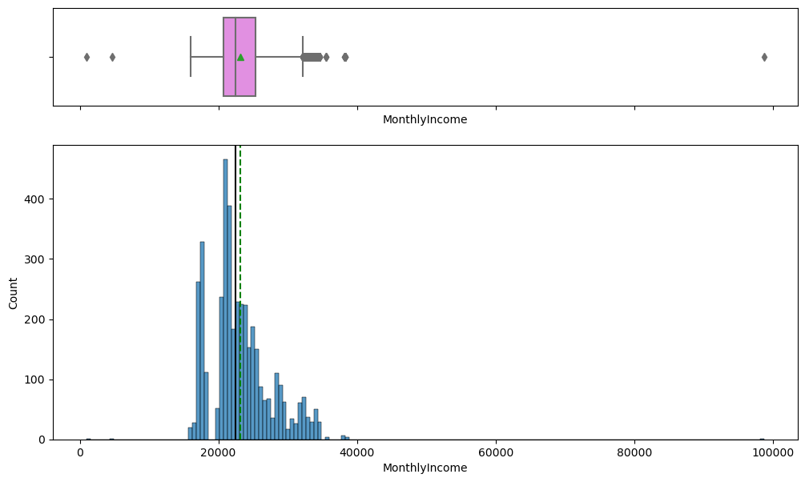

```python
histogram_boxplot(data, "MonthlyIncome")
```

People who make over 35000k are anamalous

#### Graph object types

```python
data.info()
```

[output not shown]

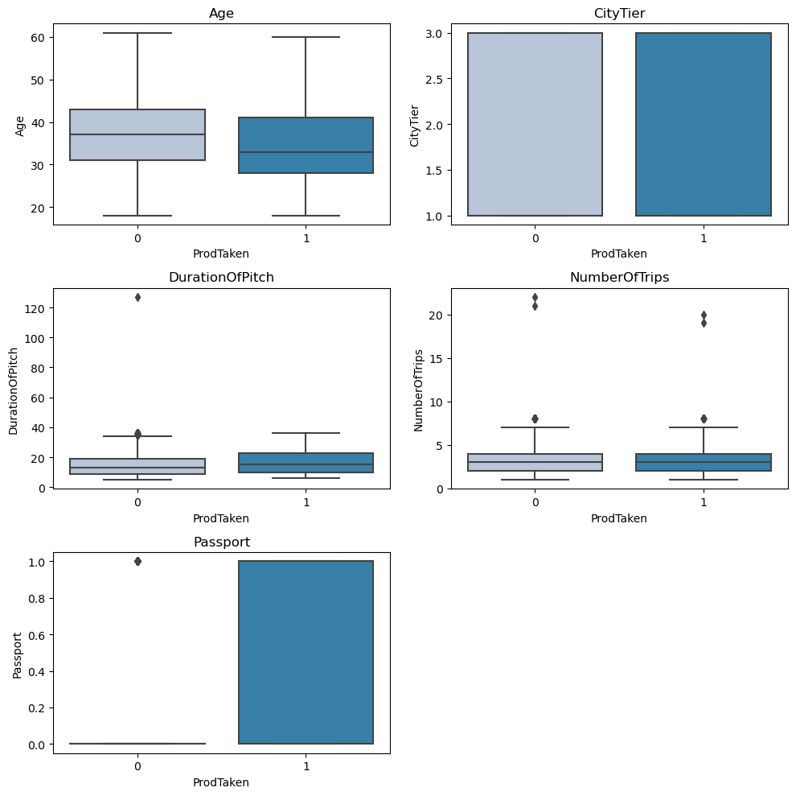

```python
cols = data[['Age','CityTier','DurationOfPitch','NumberOfTrips', 'Passport']].columns.tolist()
plt.figure(figsize=(10,10))

for i, variable in enumerate(cols):
                     plt.subplot(3,2,i+1)
                     sns.boxplot(data["ProdTaken"],data[variable],palette="PuBu")
                     plt.tight_layout()
                     plt.title(variable)
plt.show()
```

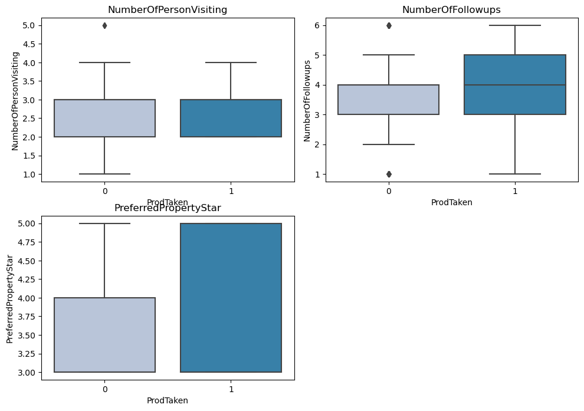

```python
cols = data[['NumberOfPersonVisiting','NumberOfFollowups', 'PreferredPropertyStar']].columns.tolist()
plt.figure(figsize=(10,10))

for i, variable in enumerate(cols):
                     plt.subplot(3,2,i+1)
                     sns.boxplot(data["ProdTaken"],data[variable],palette="PuBu")
                     plt.tight_layout()
                     plt.title(variable)
plt.show()
```

People who took the offers had a higher number of follows occur with them Prefered Property Star holders had a higher number of Packages Taken.

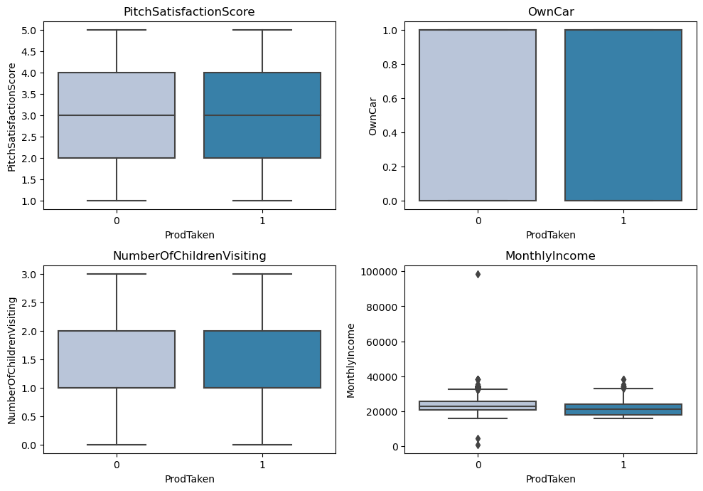

```python
cols = data[['PitchSatisfactionScore','OwnCar','NumberOfChildrenVisiting', 'MonthlyIncome']].columns.tolist()
plt.figure(figsize=(10,10))

for i, variable in enumerate(cols):
                     plt.subplot(3,2,i+1)
                     sns.boxplot(data["ProdTaken"],data[variable],palette="PuBu")
                     plt.tight_layout()
                     plt.title(variable)
plt.show()
```

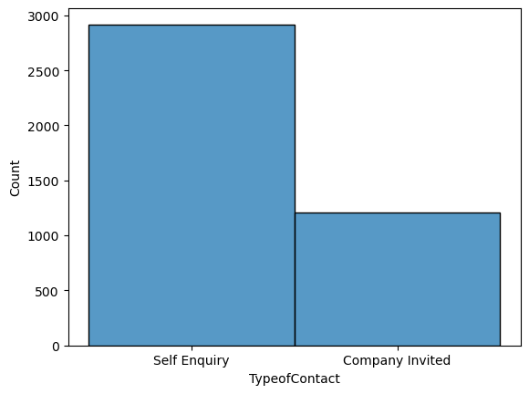

```python
sns.histplot(data=data, x="TypeofContact")
```

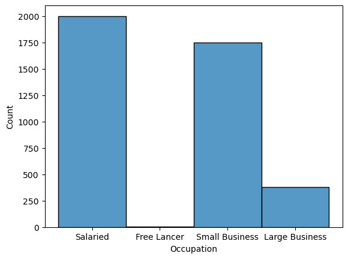

```python
sns.histplot(data=data, x="Occupation")
```

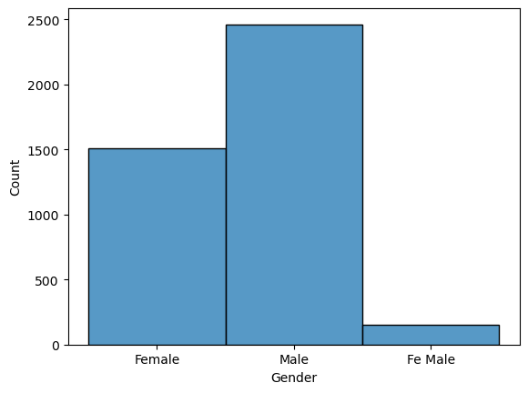

```python
sns.histplot(data=data, x="Gender")
```

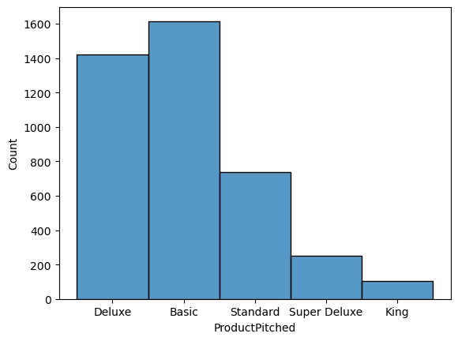

```python
sns.histplot(data=data, x="ProductPitched")
```

Basic plan is most popular

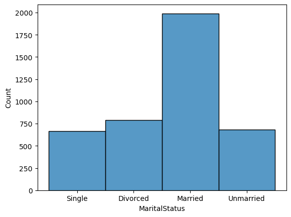

```python
sns.histplot(data=data, x="MaritalStatus")
```

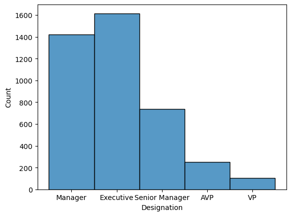

```python
sns.histplot(data=data, x="Designation")
```